# Intership project : Thorax disease classification using CNN

### 1- Description of data in the csv files

First we will start with data exploration and visualization.

#### A-Data Exploration

```python
#import the required libraries

import pandas as pd
import matplotlib.pyplot as plt
import os
import numpy as np
import seaborn as sns
%matplotlib inline
```

```python
from azureml import Workspace

ws = Workspace(workspace_id='221982f95b634a149cb857df67adf7a0',
               authorization_token='JhFyT8zG4eDUhP1GE47UmiV3p2nSRabB4PieL7DeiRHd9PeIat6bWRGcXTDBq1ntA6Q1Krvu+AWSiaAXsOa5vg==')
```

" %matplotlib inline " Is a magic function that renders the figure in a notebook (au lieu d'afficher une image de l'objet figure).

```python
#read the datasets

from azureml import Workspace
ds = ws.datasets['train.csv']
train = ds.to_dataframe()
train
```

|  | row_id | age | gender | view_position | image_name | detected |
| --- | --- | --- | --- | --- | --- | --- |
| 0 | id_0 | 45 | M | 0 | scan_0000.png | class_3 |
| 1 | id_1 | 57 | F | 0 | scan_0001.png | class_3 |
| 2 | id_10 | 58 | M | 0 | scan_00010.png | class_3 |
| 3 | id_1000 | 64 | M | 0 | scan_0001000.png | class_6 |
| 4 | id_10000 | 33 | M | 1 | scan_00010000.png | class_3 |
| 5 | id_10001 | 68 | F | 1 | scan_00010001.png | class_8 |
| 6 | id_10003 | 46 | F | 1 | scan_00010003.png | class_7 |
| 7 | id_10004 | 63 | F | 0 | scan_00010004.png | class_7 |
| 8 | id_10006 | 56 | M | 1 | scan_00010006.png | class_4 |
| 9 | id_10007 | 21 | F | 0 | scan_00010007.png | class_3 |
| 10 | id_1001 | 16 | F | 0 | scan_0001001.png | class_3 |
| 11 | id_10010 | 43 | F | 0 | scan_00010010.png | class_5 |
| 12 | id_10011 | 60 | M | 0 | scan_00010011.png | class_3 |
| 13 | id_10012 | 55 | F | 1 | scan_00010012.png | class_7 |
| 14 | id_10014 | 41 | M | 1 | scan_00010014.png | class_10 |
| 15 | id_10016 | 13 | F | 1 | scan_00010016.png | class_5 |
| 16 | id_10019 | 59 | M | 1 | scan_00010019.png | class_6 |
| 17 | id_1002 | 60 | F | 0 | scan_0001002.png | class_7 |
| 18 | id_10021 | 28 | M | 0 | scan_00010021.png | class_8 |
| 19 | id_10022 | 28 | F | 0 | scan_00010022.png | class_11 |
| 20 | id_10025 | 42 | M | 1 | scan_00010025.png | class_3 |
| 21 | id_10026 | 63 | M | 1 | scan_00010026.png | class_1 |
| 22 | id_1003 | 49 | M | 0 | scan_0001003.png | class_3 |
| 23 | id_10032 | 52 | F | 0 | scan_00010032.png | class_12 |
| 24 | id_10034 | 47 | F | 0 | scan_00010034.png | class_12 |
| 25 | id_10036 | 31 | F | 1 | scan_00010036.png | class_8 |
| 26 | id_10038 | 56 | F | 1 | scan_00010038.png | class_13 |
| 27 | id_10039 | 19 | F | 0 | scan_00010039.png | class_3 |
| 28 | id_1004 | 55 | F | 0 | scan_0001004.png | class_7 |
| 29 | id_10040 | 54 | M | 0 | scan_00010040.png | class_3 |
| ... | ... | ... | ... | ... | ... | ... |
| 18547 | id_9946 | 67 | M | 0 | scan_0009946.png | class_4 |
| 18548 | id_9949 | 41 | M | 1 | scan_0009949.png | class_6 |
| 18549 | id_9954 | 34 | M | 0 | scan_0009954.png | class_3 |
| 18550 | id_9955 | 54 | M | 1 | scan_0009955.png | class_5 |
| 18551 | id_9957 | 23 | M | 0 | scan_0009957.png | class_3 |
| 18552 | id_9958 | 67 | M | 1 | scan_0009958.png | class_12 |
| 18553 | id_9960 | 56 | M | 0 | scan_0009960.png | class_14 |
| 18554 | id_9961 | 28 | M | 0 | scan_0009961.png | class_3 |
| 18555 | id_9962 | 11 | F | 1 | scan_0009962.png | class_5 |
| 18556 | id_9966 | 58 | M | 0 | scan_0009966.png | class_12 |
| 18557 | id_9967 | 68 | M | 0 | scan_0009967.png | class_3 |
| 18558 | id_9969 | 66 | F | 1 | scan_0009969.png | class_11 |
| 18559 | id_9974 | 63 | M | 0 | scan_0009974.png | class_12 |
| 18560 | id_9977 | 35 | M | 1 | scan_0009977.png | class_2 |
| 18561 | id_9978 | 62 | F | 1 | scan_0009978.png | class_3 |
| 18562 | id_998 | 56 | M | 0 | scan_000998.png | class_11 |
| 18563 | id_9980 | 46 | F | 0 | scan_0009980.png | class_4 |
| 18564 | id_9981 | 32 | F | 1 | scan_0009981.png | class_1 |
| 18565 | id_9982 | 46 | F | 0 | scan_0009982.png | class_3 |
| 18566 | id_9984 | 33 | F | 0 | scan_0009984.png | class_3 |
| 18567 | id_9985 | 64 | M | 1 | scan_0009985.png | class_4 |
| 18568 | id_9987 | 51 | M | 1 | scan_0009987.png | class_12 |
| 18569 | id_999 | 28 | M | 1 | scan_000999.png | class_3 |
| 18570 | id_9990 | 44 | M | 1 | scan_0009990.png | class_6 |
| 18571 | id_9992 | 18 | M | 0 | scan_0009992.png | class_3 |
| 18572 | id_9993 | 43 | F | 1 | scan_0009993.png | class_12 |
| 18573 | id_9995 | 54 | F | 1 | scan_0009995.png | class_3 |
| 18574 | id_9996 | 47 | M | 1 | scan_0009996.png | class_3 |
| 18575 | id_9997 | 35 | F | 0 | scan_0009997.png | class_3 |
| 18576 | id_9999 | 40 | F | 1 | scan_0009999.png | class_6 |

18577 rows × 6 columns

```python
from azureml import Workspace
ds = ws.datasets['test.csv']
test = ds.to_dataframe()
test
```

|  | row_id | age | gender | view_position | image_name |
| --- | --- | --- | --- | --- | --- |
| 0 | id_100 | 47 | M | 0 | scan_000100.png |
| 1 | id_10002 | 28 | M | 0 | scan_00010002.png |
| 2 | id_10005 | 56 | F | 0 | scan_00010005.png |
| 3 | id_10008 | 41 | M | 1 | scan_00010008.png |
| 4 | id_10009 | 56 | F | 1 | scan_00010009.png |
| 5 | id_10013 | 39 | M | 1 | scan_00010013.png |
| 6 | id_10015 | 44 | M | 0 | scan_00010015.png |
| 7 | id_10017 | 29 | F | 0 | scan_00010017.png |
| 8 | id_10018 | 66 | M | 0 | scan_00010018.png |
| 9 | id_10020 | 68 | F | 1 | scan_00010020.png |
| 10 | id_10023 | 55 | F | 0 | scan_00010023.png |
| 11 | id_10024 | 31 | F | 1 | scan_00010024.png |
| 12 | id_10027 | 49 | F | 1 | scan_00010027.png |
| 13 | id_10028 | 64 | F | 1 | scan_00010028.png |
| 14 | id_10029 | 56 | F | 0 | scan_00010029.png |
| 15 | id_10030 | 62 | M | 0 | scan_00010030.png |
| 16 | id_10031 | 69 | M | 0 | scan_00010031.png |
| 17 | id_10033 | 23 | M | 0 | scan_00010033.png |
| 18 | id_10035 | 54 | M | 0 | scan_00010035.png |
| 19 | id_10037 | 51 | F | 1 | scan_00010037.png |
| 20 | id_10048 | 20 | F | 1 | scan_00010048.png |
| 21 | id_10050 | 11 | F | 1 | scan_00010050.png |
| 22 | id_10052 | 78 | F | 1 | scan_00010052.png |
| 23 | id_10054 | 37 | F | 1 | scan_00010054.png |
| 24 | id_10056 | 48 | M | 0 | scan_00010056.png |
| 25 | id_10057 | 45 | M | 1 | scan_00010057.png |
| 26 | id_10060 | 49 | M | 1 | scan_00010060.png |
| 27 | id_10061 | 42 | F | 0 | scan_00010061.png |
| 28 | id_10063 | 65 | M | 0 | scan_00010063.png |
| 29 | id_10068 | 21 | F | 1 | scan_00010068.png |
| ... | ... | ... | ... | ... | ... |
| 12356 | id_9943 | 21 | F | 1 | scan_0009943.png |
| 12357 | id_9947 | 72 | F | 0 | scan_0009947.png |
| 12358 | id_9948 | 43 | M | 0 | scan_0009948.png |
| 12359 | id_995 | 47 | M | 1 | scan_000995.png |
| 12360 | id_9950 | 12 | F | 0 | scan_0009950.png |
| 12361 | id_9951 | 67 | F | 1 | scan_0009951.png |
| 12362 | id_9952 | 56 | F | 1 | scan_0009952.png |
| 12363 | id_9953 | 66 | F | 0 | scan_0009953.png |
| 12364 | id_9956 | 49 | M | 0 | scan_0009956.png |
| 12365 | id_9959 | 23 | M | 1 | scan_0009959.png |
| 12366 | id_996 | 34 | F | 1 | scan_000996.png |
| 12367 | id_9963 | 43 | F | 0 | scan_0009963.png |
| 12368 | id_9964 | 22 | F | 0 | scan_0009964.png |
| 12369 | id_9965 | 53 | M | 1 | scan_0009965.png |
| 12370 | id_9968 | 53 | M | 1 | scan_0009968.png |
| 12371 | id_997 | 39 | M | 1 | scan_000997.png |
| 12372 | id_9970 | 43 | F | 1 | scan_0009970.png |
| 12373 | id_9971 | 39 | M | 1 | scan_0009971.png |
| 12374 | id_9972 | 49 | M | 1 | scan_0009972.png |
| 12375 | id_9973 | 59 | M | 1 | scan_0009973.png |
| 12376 | id_9975 | 56 | M | 0 | scan_0009975.png |
| 12377 | id_9976 | 33 | M | 0 | scan_0009976.png |
| 12378 | id_9979 | 64 | F | 1 | scan_0009979.png |
| 12379 | id_9983 | 55 | M | 1 | scan_0009983.png |
| 12380 | id_9986 | 77 | M | 0 | scan_0009986.png |
| 12381 | id_9988 | 44 | M | 0 | scan_0009988.png |
| 12382 | id_9989 | 67 | M | 0 | scan_0009989.png |
| 12383 | id_9991 | 61 | F | 1 | scan_0009991.png |
| 12384 | id_9994 | 53 | F | 1 | scan_0009994.png |
| 12385 | id_9998 | 60 | F | 1 | scan_0009998.png |

12386 rows × 5 columns

```python
# Information of the first ten patients stored in train.csv

train.head(10)
```

|  | row_id | age | gender | view_position | image_name | detected |
| --- | --- | --- | --- | --- | --- | --- |
| 0 | id_0 | 45 | M | 0 | scan_0000.png | class_3 |
| 1 | id_1 | 57 | F | 0 | scan_0001.png | class_3 |
| 2 | id_10 | 58 | M | 0 | scan_00010.png | class_3 |
| 3 | id_1000 | 64 | M | 0 | scan_0001000.png | class_6 |
| 4 | id_10000 | 33 | M | 1 | scan_00010000.png | class_3 |
| 5 | id_10001 | 68 | F | 1 | scan_00010001.png | class_8 |
| 6 | id_10003 | 46 | F | 1 | scan_00010003.png | class_7 |
| 7 | id_10004 | 63 | F | 0 | scan_00010004.png | class_7 |
| 8 | id_10006 | 56 | M | 1 | scan_00010006.png | class_4 |
| 9 | id_10007 | 21 | F | 0 | scan_00010007.png | class_3 |

#### B-Exploratory Visualization

To explore our dataset and to get a better understanding of it , we will use seaborn and matplotlib libraries which will help us with visual graphs and plots to produce our visualisations. As a first step, we will represent the distribution of the target variable to check if the dataset is umbalanced .

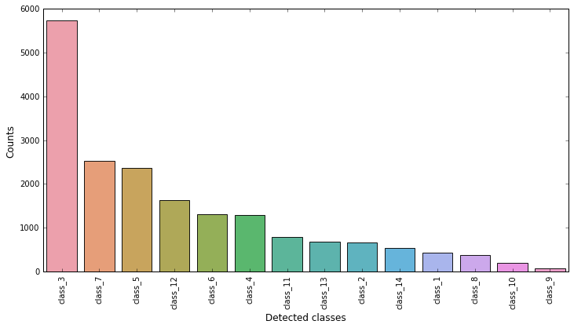

```python
#Distribution of the target variable 'detected'.

detected_counts = train.detected.value_counts()
plt.figure(figsize = (12,6))
sns.barplot(detected_counts.index, detected_counts.values, alpha = 0.9)
plt.xticks(rotation = 'vertical')
plt.xlabel('Detected classes', fontsize =12)
plt.ylabel('Counts', fontsize = 12)
plt.show()
```

This figure shows the occurrence (frequency) of each class in the target variable of the training dataset, sorted in the descending order. We can see that class_3 type thorax disease is more prominent in patients, while class_9 type thorax disease is quite rare ==> the training dataset is umbalanced .

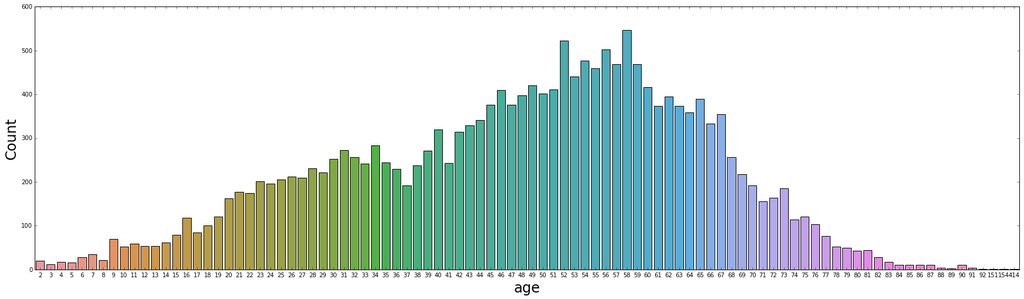

```python
#Distribution of the variable 'age'.

ax = plt.figure(figsize=(30, 8))
sns.countplot(train.age)
axis_font = {'fontname':'Arial', 'size':'24'}
plt.xlabel('age',  **axis_font)
plt.ylabel('Count',  **axis_font)
```

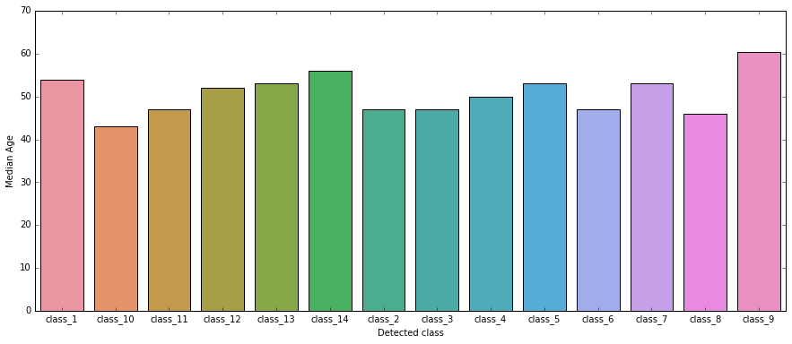

```python
#Distribution of the variable 'age' over the target variable.

temp = train.groupby(['detected']).median()
ax = plt.figure(figsize=(15, 6))
sns.barplot(temp.index, temp.age)
plt.xlabel('Detected class')
plt.ylabel('Median Age')
```

Finally we represent the median age of patients for each type of class in the ‘detected’ (target) variable, the figure obtained shows that class_9 type thorax disease is common in patients over the age of 60. NB: We calculate the median of the variable ‘age’ for each target class, instead of the mean because of outliers in the data.

# OpenCV (Open Source Computer Vision Library)

OpenCV is a library for image manipulation , such as PILLOW, PIL, or skimage .It is used for Computer Vision because unlike humans, a computer cannot recognise the shapes or the colors of an image .SO , any image is read as an array of numbers (une matrice de pixel).In our training dataset each image is of the shape (1024, 1024, 3), where the first two numbers represent the number of rows and columns of pixels and Number 3 represents the RGB color spectrum (Spectre de couleur RVB : Rouge , vert et bleu ). As we said before that an image is read as an array of numbers so each number in this array represents a single pixel.

```python
#Load and visualise the image data USING Open CV.

TRAIN_PATH = 'C:/Users/nabil/Desktop/comptimage/train_/'
TEST_PATH = 'C:/Users/nabil/Desktop/comptimage/test_/'
```

```python
!pip install opencv-python
import cv2
```

```
You are using pip version 9.0.3, however version 18.0 is available.
```

The next steps were done on my laptop :

### 2- Data Preprocessing ( Pré-traitement des données )

We musn't forget that our dataset contains 18,577 images of size (1024,1024,3) each , so processing all these images requires enormous computation power that's why we have to resize them to more appropriate sizes to facilitate the calculation . We have decided to resize each image to (128,128,3) dimensions. And to do that we will create a function, which reads an image, resizes it to 128 x128 dimensions and then returns it.

```python
#img = cv2.imread(TRAIN_PATH + 'scan_0000.png')
#print(img.shape)
#plt.imshow(img)

#the function definition
#def read_img(img_path):
    #img = cv2.imread(img_path)
    #img = cv2.resize(img, (128, 128))
    #return img

#from tqdm import tqdm
#train_img = []
#for img_path in tqdm(train['image_name'].values):
    #train_img.append(read_img(TRAIN_PATH + img_path))
    #train_image
```

After finishing this steps i imported the dataset.zip to my notebook and unzip it to continue the work

```python
#from azureml import Workspace
#ws = Workspace()
```

```python
from io import BytesIO
import zipfile
with zipfile.ZipFile(BytesIO(ws.datasets["train_img.zip"].read_as_binary()),"r") as zip_ref:
    zip_ref.extractall('/home/nbuser/')
```

```python
import os
!ls '/home/nbuser/'
```

```
anaconda2_20  anaconda3_23  library  R	train_img.npy
```

```python
import numpy as np
train_img = np.load('/home/nbuser/train_img.npy')
```

```python
train_img
```

```
array([[[[ 89,  89,  89],
         [ 95,  95,  95],
         [ 86,  86,  86],
         ...,
         [  6,   6,   6],
         [  6,   6,   6],
         [  5,   5,   5]],

        [[126, 126, 126],
         [100, 100, 100],
         [ 96,  96,  96],
         ...,
         [  8,   8,   8],
         [  8,   8,   8],
         [  8,   8,   8]],

        [[123, 123, 123],
         [104, 104, 104],
         [105, 105, 105],
         ...,
         [ 10,  10,  10],
         [ 10,  10,  10],
         [ 10,  10,  10]],

        ...,

        [[224, 224, 224],
         [221, 221, 221],
         [223, 223, 223],
         ...,
         [ 49,  49,  49],
         [ 18,  18,  18],
         [ 34,  34,  34]],

        [[225, 225, 225],
         [221, 221, 221],
         [221, 221, 221],
         ...,
         [ 48,  48,  48],
         [ 19,  19,  19],
```

[output cut: 252 more lines]

```
        [[  5,   5,   5],
         [  4,   4,   4],
         [  3,   3,   3],
         ...,
         [  3,   3,   3],
         [  3,   3,   3],
         [ 11,  11,  11]],

        [[  8,   8,   8],
         [  4,   4,   4],
         [  3,   3,   3],
         ...,
         [  3,   3,   3],
         [  5,   5,   5],
         [ 17,  17,  17]]]], dtype=uint8)
```

Before any other preprocessing we will rescale our image data because as we know that our original images are made of RGB coefficients lying in the range 0–255 and to process our models , such values will be too high so we target values between 0 and 1 instead by scaling with a 1/255 factor(Pour résoudre ce problème on va remplacez les coefficients du RGB qui varient entre 0 et 255 par des 0 et 1 en les multipliant par le facteur 1/255) .

```python
#Rescaling the images
xtrain = []
```

```python
xtrain = np.array(train_img[:1000], np.float32) / 255.
```

```python
#xtrain1 = np.array(train_img[5000:10000], np.float32) / 255.
```

```python
#xtrain2 = np.array(train_img[10000:12000], np.float32) / 255.
```

```python
#import numpy as np
#np.save('xtrain', xtrain) # save the file as "outfile_name.npy"
```

```python
#np.vstack(( xtrain, xtrain1))
```

Now we calculate the mean and the std of all the training images and we will explaine later the reason of calculating them . We start by calculating the mean image of our dataset which is calculated by taking the mean values for each pixel across all training examples.

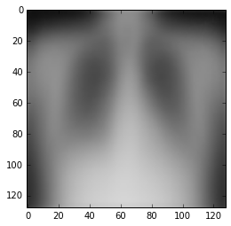

```python
#Mean of the images of xtrain

mean_img = np.mean(xtrain, axis=0)
plt.imshow(mean_img)
```

We find a good average representation of the entire training dataset : an image of a thorax. This image lets us conclude that all the images are somewhat aligned to the center and they have comparable sizes.

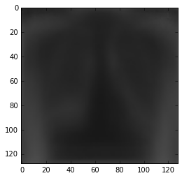

```python
#Next we calculate the std of all the images :
std_img = np.std(xtrain, axis=0)
plt.imshow(std_img)
```

We notice that High variance shows up whiter (Cela veut dire que les parties les plus claires représentent une variance(différence) importante entre les images. Et d'aprés l'image trouvée on remarque que ces parties sont au niveau des poumons là où on detecte la maladie et où les patients se différencient entre eux (de maladie de classe_1 à maladie de classe_14 ) par rapport au reste de l'image .

## Data normalisation

In this level of work we will explaine the reason of calculating the mean and the std of all the training images. We know that during the process of training our network, we are going to be multiplying (weights) and adding (biases) to these initial inputs to cause activations, which get back-propagated with the gradients to train the model and We want that each feature to have a similar range so that our gradients don’t go out of control (and we only need one global learning rate multiplier). For that reason we have decided to normalize both our train and test datasets.The formula we used to do that is :

```
                                                $X = {(x-μ)}/{σ}$
```

Where :

$x = Input array$

$μ = Mean value$

$σ = Standard deviation$

$X = Output/Resultant array$

```python
#Normalization of xtrain1

xtrain_norm = (xtrain - mean_img) / std_img
xtrain_norm.shape
xtrain_norm
```

```
array([[[[ 5.0291514e-01,  5.0291514e-01,  5.0291514e-01],
         [ 8.3925986e-01,  8.3925986e-01,  8.3925986e-01],
         [ 8.6027867e-01,  8.6027867e-01,  8.6027867e-01],
         ...,
         [-6.3066036e-01, -6.3066036e-01, -6.3066036e-01],
         [-6.4734179e-01, -6.4734179e-01, -6.4734179e-01],
         [-7.0390815e-01, -7.0390815e-01, -7.0390815e-01]],

        [[ 1.5181605e+00,  1.5181605e+00,  1.5181605e+00],
         [ 1.5280799e+00,  1.5280799e+00,  1.5280799e+00],
         [ 1.6395575e+00,  1.6395575e+00,  1.6395575e+00],
         ...,
         [-4.9025458e-01, -4.9025458e-01, -4.9025458e-01],
         [-5.0866050e-01, -5.0866050e-01, -5.0866050e-01],
         [-5.7111853e-01, -5.7111853e-01, -5.7111853e-01]],

        [[ 1.8652544e+00,  1.8652544e+00,  1.8652544e+00],
         [ 1.8912380e+00,  1.8912380e+00,  1.8912380e+00],
         [ 2.1336453e+00,  2.1336453e+00,  2.1336453e+00],
         ...,
         [-3.2806829e-01, -3.2806829e-01, -3.2806829e-01],
         [-3.4601811e-01, -3.4601811e-01, -3.4601811e-01],
         [-4.1089121e-01, -4.1089121e-01, -4.1089121e-01]],

        ...,

        [[ 2.4693713e+00,  2.4693713e+00,  2.4693713e+00],
         [ 2.5534654e+00,  2.5534654e+00,  2.5534654e+00],
         [ 2.5454161e+00,  2.5454161e+00,  2.5454161e+00],
         ...,
         [-7.2675049e-02, -7.2675049e-02, -7.2675049e-02],
         [-5.6617808e-01, -5.6617808e-01, -5.6617808e-01],
         [-4.0608200e-01, -4.0608200e-01, -4.0608200e-01]],

        [[ 2.3830667e+00,  2.3830667e+00,  2.3830667e+00],
         [ 2.4385900e+00,  2.4385900e+00,  2.4385900e+00],
         [ 2.3963506e+00,  2.3963506e+00,  2.3963506e+00],
         ...,
         [-1.0255735e-01, -1.0255735e-01, -1.0255735e-01],
         [-5.5685437e-01, -5.5685437e-01, -5.5685437e-01],
```

[output cut: 253 more lines]

```
         [ 1.8348805e+00,  1.8348805e+00,  1.8348805e+00],
         [ 1.8276070e+00,  1.8276070e+00,  1.8276070e+00],
         ...,
         [ 1.4438567e+00,  1.4438567e+00,  1.4438567e+00],
         [ 1.3949656e+00,  1.3949656e+00,  1.3949656e+00],
         [ 1.2695602e+00,  1.2695602e+00,  1.2695602e+00]],

        [[ 1.6020476e+00,  1.6020476e+00,  1.6020476e+00],
         [ 1.7046106e+00,  1.7046106e+00,  1.7046106e+00],
         [ 1.6959434e+00,  1.6959434e+00,  1.6959434e+00],
         ...,
         [ 1.2529342e+00,  1.2529342e+00,  1.2529342e+00],
         [ 1.3025274e+00,  1.3025274e+00,  1.3025274e+00],
         [ 1.2888710e+00,  1.2888710e+00,  1.2888710e+00]]]],
      dtype=float32)
```

## The Target encoding

NB: for categorical variables, integer encoding is not enough. In fact, using this encoding and allowing the model to assume a natural ordering between categories may result in poor performance or unexpected results.Therefore, we apply one-hot encoding to the integer representation of the categories .

```python
#!pip install tensorflow --upgrade --force-reinstall
```

```python
import tensorflow
```

```python
import tensorflow as tf
```

```python
tf.VERSION
```

```
'1.10.0'
```

```python
#Encoding the target variable as integers

class_list = train['detected'].tolist()
Y_train = {k:v+1 for v,k in enumerate(set(class_list))}
y_train = [Y_train[k] for k in class_list]
y_train
```

```
[7,
 7,
 7,
 9,
 7,
 13,
 10,
 10,
 11,
 7,
 7,
 12,
 7,
 10,
 2,
 12,
 9,
 10,
 13,
 3,
 7,
 8,
 7,
 4,
 4,
 13,
 5,
 7,
 10,
 7,
 11,
 12,
 7,
 10,
 3,
 7,
 13,
 7,
 12,
 10,
```

[output cut: 946 more lines]

```
 7,
 11,
 7,
 10,
 12,
 12,
 6,
 11,
 3,
 11,
 10,
 10,
 7,
 7,
 ...]
```

```python
#One-hot encoding the target variable.
from tensorflow import keras
y_train = keras.utils.to_categorical(y_train)
y_train
```

```
array([[0., 0., 0., ..., 0., 0., 0.],
       [0., 0., 0., ..., 0., 0., 0.],
       [0., 0., 0., ..., 0., 0., 0.],
       ...,
       [0., 0., 0., ..., 0., 0., 0.],
       [0., 0., 0., ..., 0., 0., 0.],
       [0., 0., 0., ..., 0., 0., 0.]], dtype=float32)
```

```python
ytrain =  y_train[:1000]
ytrain
```

```
array([[0., 0., 0., ..., 0., 0., 0.],
       [0., 0., 0., ..., 0., 0., 0.],
       [0., 0., 0., ..., 0., 0., 0.],
       ...,
       [0., 0., 0., ..., 0., 0., 0.],
       [0., 0., 0., ..., 0., 0., 0.],
       [0., 0., 0., ..., 0., 0., 0.]], dtype=float32)
```